# Colorado 14ers

- Show All Code
- Hide All Code
- View Source

Exploration Using Plots in ggplot2

Author

Haley Brumberger

Published

February 7, 2026

# 1 Setup

Using R version 4.5.2 (2025-10-31) , R Core Team (2022), and ggplot2 version 4.0.0 from the tidyverse (Wickham et al. 2019).

```r
# load packages
library(readr)
library(ggplot2)

# load script files
```

# 2 Data

```r
# load data
#| label: data load

# read in data and don't show col types to suppress message
co14s <- read_csv("data/colorado_14s.csv", show_col_types = FALSE)
```

# 3 Plots

The figures below display data about Colorado mountains over 14,000 feet (14ers), plus a few non-14ers.

Figure 1 shows distance in miles vs. elevation gain in feet; the points are colored by the difficulty of the trail and shaped (circle or triangle) according to whether the mountain is a 14er or not.

Figure 2 shows elevation in feet vs. prominence in feet; the points are colored by the difficulty of the trail and shaped by the range of which the mountain is part.

Figure 3 shows longitude vs. latitude; the points are colored by elevation in feet and shaped by the range of which the mountain is part.

## 3.1 Distance vs. Elevation Gain

Figure 1 (below) shows Distance in miles vs. Elevation gain in feet and includes an evaluation of trail difficulty using “classes” (and also shows whether the mountain is above or below 14,000 feet). It seems intuitive that the longer and higher the trail/mountain is, the harder it would be (higher class). However, steepness factors in–shorter trails that are steeper are harder; therefore, those above the line of best fit, whose slope is approximately 250 ft/mi, include more “hard” or higher class trails. Additionally, most of the mountains with 2000-4000 ft of elevation gain and trails of <10 miles are considered Class 2, while above those thresholds, the classes are more variable, likely dependent on steepness. You can see the three 14ers that are outliers (furthest below the line of best fit), at about 13-14 mi and 3500 ft elevation gain, 22 mi and ~5900 ft elevation gain, and 26 mi and ~7500 ft elevation gain; these outliers include two Class 1s and one Hard Class 3. The Hard Class 3 is below the line of best fit, but the difficulty evaluation also factors in things like how well-marked the trail is, so it’s possible that even though this trail might be less steep, it is still harder than other, better-marked trails.

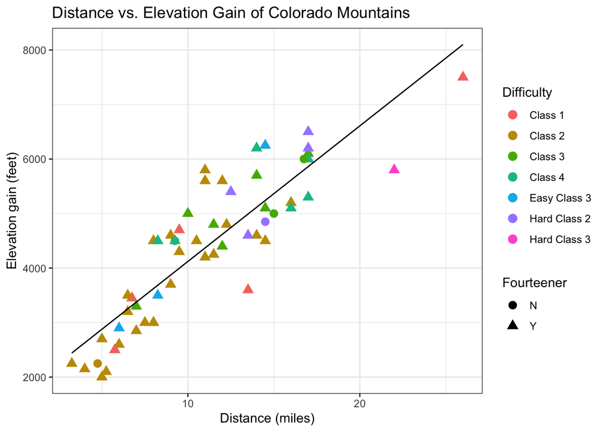

Figure 1: Colorado 14ers Distance (mi) vs. Elevation gain (ft), colored by Difficulty, shaped by Fourteener (y/n).

```r
ggplot(co14s) +
  aes(x = Distance_mi, y = `Elevation Gain_ft`, color = Difficulty, shape = fourteener) + # map x and y variables to plot distance vs elevation gain, visualize by color (diffculty) and shape (fourteener)
  geom_point(size = 3) + # increase size of points to make larger
  geom_smooth(aes(group = 1, shape = NULL), method = lm, se = FALSE, color = "black", linewidth = 0.5) + # add a line of best fit and drop 'shape' aesthetic to get rid of warning message about geom_smooth()
  theme_bw() + # add theme to make plot prettier
  labs( # add axis titles and make sure the mapped "shape" legend engry has a capitalized "F" in Fourteener
    x = "Distance (miles)",
    y = "Elevation gain (feet)",
    title = "Distance vs. Elevation Gain of Colorado Mountains",
    shape = "Fourteener"
  )
```

## 3.2 Elevation vs. Prominence

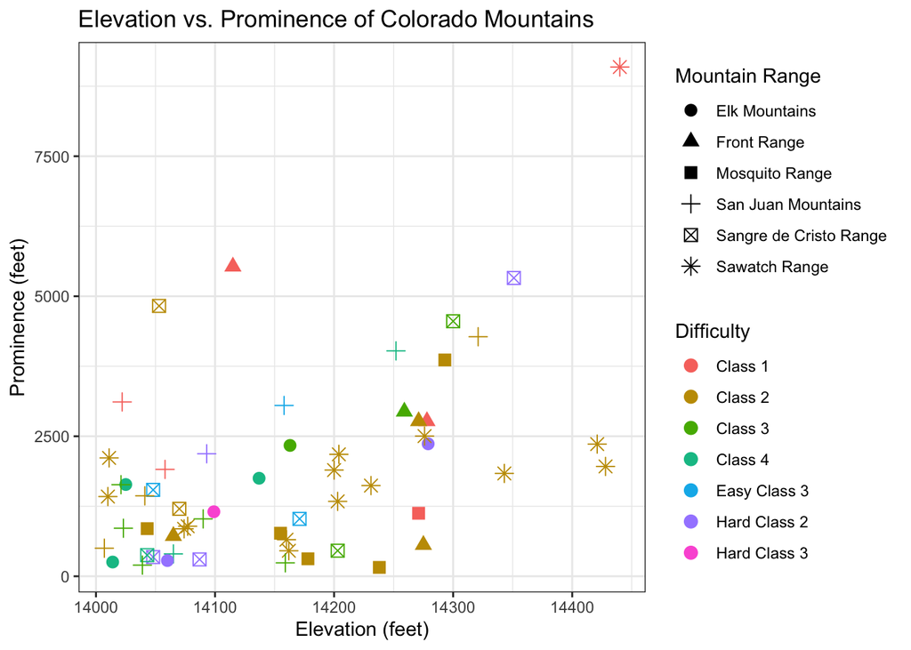

Figure 2: Colorado 14ers Elevation (ft) vs. Prominence (ft), colored by Difficulty, shaped by Mountain Range.

```r
ggplot(co14s) +
  aes(x = Elevation_ft, y = Prominence_ft, color = Difficulty, shape = `Mountain Range`) + # map x and y variables to plot elevation vs. prominence, visualize by color (diffculty) and shape (mountain range)
  geom_point(size = 3) + # make points bigger to be more legible
  theme_bw() + #change theme to make plot prettier
  labs( # add axis and plot titles
    x = "Elevation (feet)",
    y = "Prominence (feet)",
    title = "Elevation vs. Prominence of Colorado Mountains",
  )
```

## 3.3 Longitude vs. Latitude

Figure 3 (below) basically shows the geographic distribution of Colorado mountains/14ers (latitude and longitude). It is colored by elevation in feet and shaped by Mountain Range (the latter similar to Figure 2). This graph is the easiest to understand because the mountains in each range group together, which makes sense from a geographic perspective: all the Elk Mountains should be close together, as should be those in the San Juans, the Mosquitos, the Front Range, etc.. Interestingly, the elevations for each range seem to vary less than I would have expected–most are within 100-200 ft of one another within a range–but this does make sense considering geographic proximity. Of course, there are exceptions: the Sawatch Range has a big range in elevations, from lowest to highest (darkest to lightest blue).

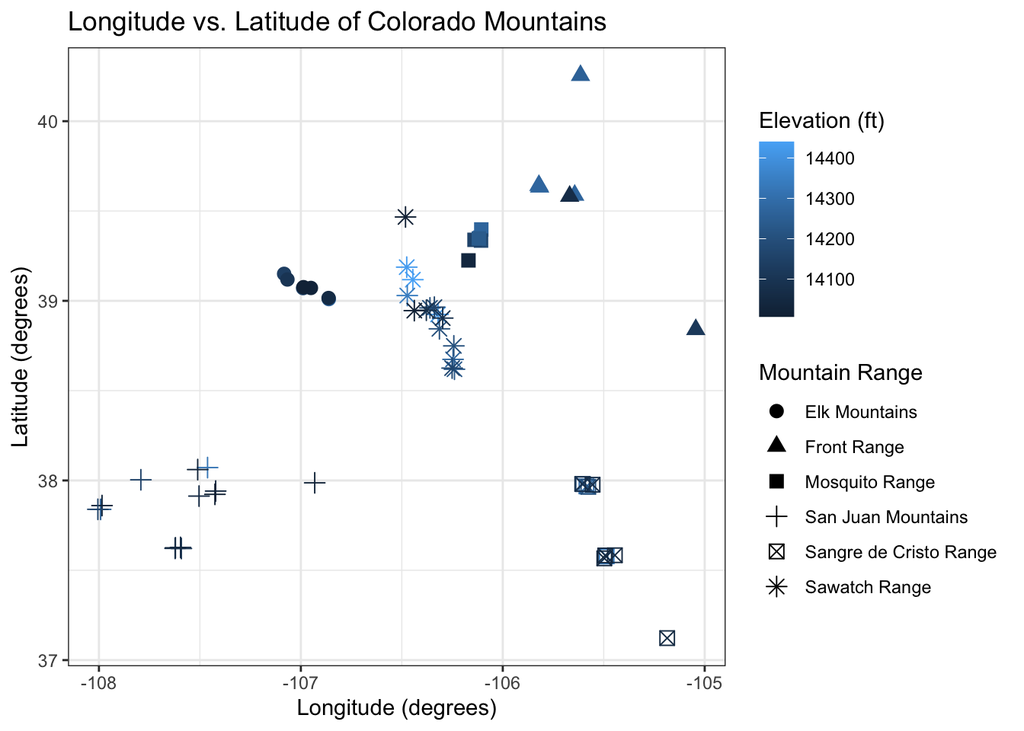

Figure 3: Colorado 14ers Longitude vs. Latitude, colored by Elevation (ft), shaped by Mountain Range.

```r
ggplot(co14s) +
  aes(x = Long, y = Lat, color = Elevation_ft, shape = `Mountain Range`) +  # map x and y variables to plot longitude vs latitude, visualize by color (elevation) and shape (mountain range)
  geom_point(size = 3) + # increase size of points for legibility
  theme_bw() + # add theme to make plot prettier
  labs( # add axes titles and ensure the mapped "color" legend entry has proper formatting
    x = "Longitude (degrees)",
    y = "Latitude (degrees)",
    title = "Longitude vs. Latitude of Colorado Mountains",
    color = "Elevation (ft)"
  )
```

# 4 References

R Core Team. 2022. *R: A Language and Environment for Statistical Computing*. Vienna, Austria: R Foundation for Statistical Computing. https://www.R-project.org/.

Wickham, Hadley, Mara Averick, Jennifer Bryan, Winston Chang, Lucy D’Agostino McGowan, Romain François, Garrett Grolemund, et al. 2019. “Welcome to the tidyverse.” *Journal of Open Source Software* 4 (43): 1686. https://doi.org/10.21105/joss.01686.